# Project: Analyze a public dataset

Marie Hannaert

2024-03-24

```r
#settings for the whole script
knitr::opts_chunk$set(echo = TRUE, warning = FALSE, message = FALSE)
#loading in the data
setwd("C:/Users/11901250/Documents/SF/BIT08-Data_R/Assignment_algae/") #windows
algae_data <- read.csv(file="algae.csv", header = TRUE)
```

```r
#these are the packages that are needed for the script below
pkg <- installed.packages()[, "Package"]
if(!('RColorBrewer' %in% pkg)) { install.packages("RColorBrewer") }
library(RColorBrewer)
if(!('ggplot2' %in% pkg)) { install.packages("ggplot2") }
library(ggplot2)
if(!('highcharter' %in% pkg)) { install.packages("highcharter") }
library(highcharter)
if(!('gridExtra' %in% pkg)) { install.packages("gridExtra") }
library(gridExtra)
if(!('PerformanceAnalytics' %in% pkg)) { install.packages("PerformanceAnalytics") }
library(PerformanceAnalytics)
```

## Erudit dataset: Algae concentration evaluation

## Introduction dataset

```r
#create matrix from the varaibales and there explanation
#selecting all the variable names
variables <- colnames(algae_data)
#creating a vector with the explanation
explanation <- c("ID column","The season when it was observed ", "The size of the river","The speed at which the water in the river is flowing", "Maximum pH value", "Minimum value of oxygen", "Average value of chloride", "Average value of nitrates", "Average value of ammonium", "Average of orthophosphate","Average of total phosphate", "Average chlorophyll", rep("algae species number", times=7) )
tab <- matrix(explanation, ncol=1, byrow=TRUE)

#define column names and row names of matrix
colnames(tab) <- ("Explanation")
rownames(tab) <- variables

#convert matrix to table
tab <- as.table(tab)

#making a nice table
knitr::kable(tab,
caption = "Table of variables")
```

Table of variables

|  | Explanation |
| --- | --- |
| X | ID column |
| season | The season when it was observed |
| size | The size of the river |
| speed | The speed at which the water in the river is flowing |
| mxPH | Maximum pH value |
| mnO2 | Minimum value of oxygen |
| Cl | Average value of chloride |
| NO3 | Average value of nitrates |
| NH4 | Average value of ammonium |
| oPO4 | Average of orthophosphate |
| PO4 | Average of total phosphate |
| Chla | Average chlorophyll |
| a1 | algae species number |
| a2 | algae species number |
| a3 | algae species number |
| a4 | algae species number |
| a5 | algae species number |
| a6 | algae species number |
| a7 | algae species number |

The data has been prepared for further analysis. First, I removed all the NA data to avoid any issues in further analysis. Secondly, I removed the ID column since it does not provide useful information for the subsequent analysis.

Since many of the graphs involve seasons, I created a color vector to represent them. This is handy because the seasons will always have the same color in every graph, making them easy to identify.

```r
#removing NA data
algae_data <- na.omit(algae_data)
#removing meaningless column
algae_data <- subset(algae_data, select = -X)
#giving an overview of the structure of the dataset
str(algae_data)
```

```
## 'data.frame':    184 obs. of  18 variables:
##  $ season: chr  "winter" "spring" "autumn" "spring" ...
##  $ size  : chr  "small" "small" "small" "small" ...
##  $ speed : chr  "medium" "medium" "medium" "medium" ...
##  $ mxPH  : num  8 8.35 8.1 8.07 8.06 8.25 8.15 8.05 8.7 7.93 ...
##  $ mnO2  : num  9.8 8 11.4 4.8 9 13.1 10.3 10.6 3.4 9.9 ...
##  $ Cl    : num  60.8 57.8 40 77.4 55.4 ...
##  $ NO3   : num  6.24 1.29 5.33 2.3 10.42 ...
##  $ NH4   : num  578 370 346.7 98.2 233.7 ...
##  $ oPO4  : num  105 428.8 125.7 61.2 58.2 ...
##  $ PO4   : num  170 558.8 187.1 138.7 97.6 ...
##  $ Chla  : num  50 1.3 15.6 1.4 10.5 ...
##  $ a1    : num  0 1.4 3.3 3.1 9.2 15.1 2.4 18.2 25.4 17 ...
##  $ a2    : num  0 7.6 53.6 41 2.9 14.6 1.2 1.6 5.4 0 ...
##  $ a3    : num  0 4.8 1.9 18.9 7.5 1.4 3.2 0 2.5 0 ...
##  $ a4    : num  0 1.9 0 0 0 0 3.9 0 0 2.9 ...
##  $ a5    : num  34.2 6.7 0 1.4 7.5 22.5 5.8 5.5 0 0 ...
##  $ a6    : num  8.3 0 0 0 4.1 12.6 6.8 8.7 0 0 ...
##  $ a7    : num  0 2.1 9.7 1.4 1 2.9 0 0 0 1.7 ...
```

```r
#colors for seasons
brewer.pal(4,"Set2")
```

```
## [1] "#66C2A5" "#FC8D62" "#8DA0CB" "#E78AC3"
```

```r
season.col <- c("#FC8D62","#E78AC3","#66C2A5","#8DA0CB")
```

## Taking a look at the measurement of the rivers

To take a look at the stage of the rivers where the measurements were taken. First there are three bar plots for each categorical data and these per season. Then there are eight histograms for each of the numerical measures of the river. The first bar plot shows that most of the samples are taken in the winter and the least in the autumn. The other two bar plots show that most of the samples come from a medium sized river with a speed that is between medium and high.

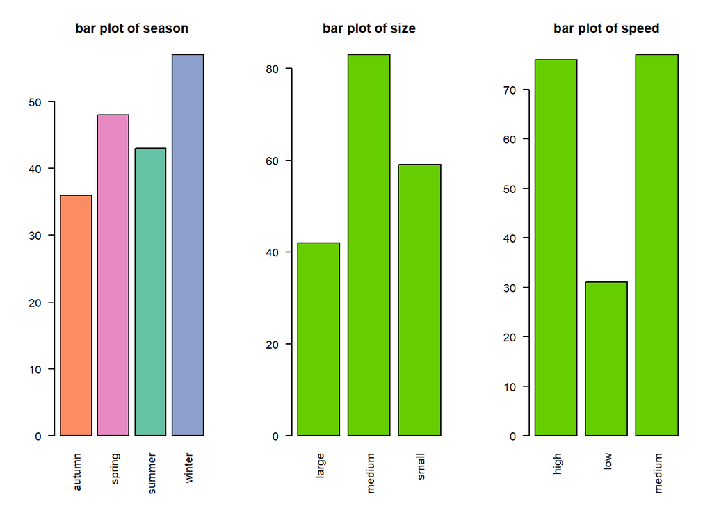

```r
#making that the bar plot are printed with three next to each other
par(mfrow = c(1,3))
#bar plot with colors for every season
season.freq <- table(algae_data[,1])
barplot(season.freq,
        main = paste0("bar plot of season"),
        las=2,
        col = season.col
)
#selecting the needed columns out of the dataframe
cat_algae <- colnames(algae_data[,2:3])
#for loop for making bar plots of the last two categorical columns
for(cat_algae in cat_algae) {
  cat_algae.freq <- table(algae_data[,cat_algae])
  barplot(cat_algae.freq,
          main = paste0("bar plot of ",cat_algae),
          las=2,
          col ="chartreuse3"
  )}
```

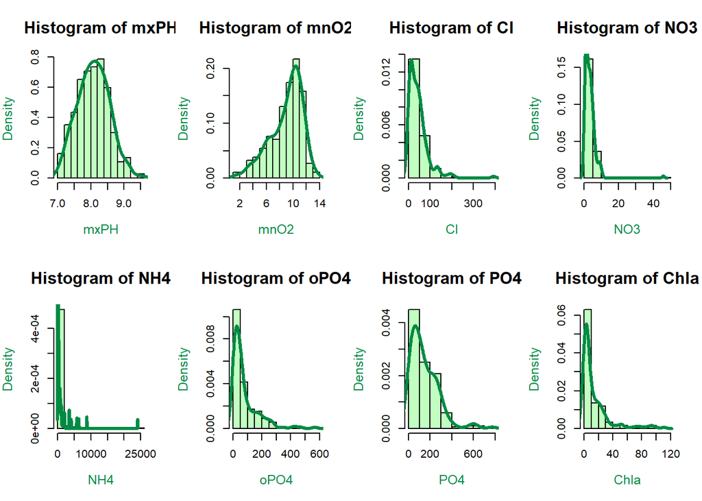

```r
#making that the plots are printed besides each other in two rows of four
par(mfrow = c(2,4))
#selecting the columns I need for making the histograms
num_algae <- colnames(algae_data[,4:11])
#for loop to make histograms and density plot of the numerical columns, but only the measurements of the river
for(num_algae in num_algae) {
  d <- density(algae_data[,num_algae])
  hist(algae_data[,num_algae],
       main = paste0("Histogram of ",num_algae),
       xlab = num_algae,
       freq = FALSE,
     cex.main = 1.5,
     cex.lab = 1.2,
     col = "darkseagreen1",
     col.lab = "springgreen4")
  lines(d, lty = 1, lwd = 3, col = "springgreen4")
}
```